# Covid Spread Simulator

How dangerous is a shopping trip? What happens if you are in an in-person meeting? What happens at a conference? What happens at home?

Let’s simulate all this

```r
lambda <- function(timePeriod, p = 0.5) {
  # timePeriod, in hours, is the period of time you need to spend with an infected person in order to have a *p* chance of get infected yourself
  return(- log (1-p)/timePeriod)
}
```

```r
transmissionProb <- function(timePeriod, lambda) {
  # When the disease spreads with a parameter lambda, what is the likelihood you'll get infected when you spend *timePeriod* hours with an infected person?
  return(1 - exp(-lambda * timePeriod))
}
```

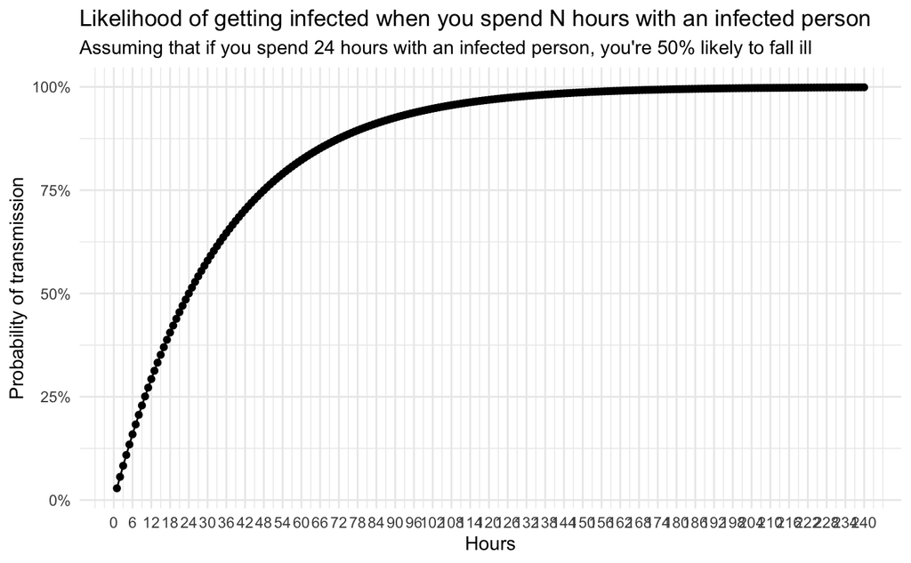

```r
lambda1 <- lambda(24)
tibble(Time=1:240) %>%
  mutate(Prob=transmissionProb(Time, lambda1)) %>%
  ggplot(aes(x=Time, y=Prob)) + geom_point() + geom_line() + theme_minimal() + scale_y_continuous("Probability of transmission", labels=scales::percent) + ggtitle("Likelihood of getting infected when you spend N hours with an infected person", subtitle = "Assuming that if you spend 24 hours with an infected person, you're 50% likely to fall ill") + scale_x_continuous("Hours", breaks=seq(0,240,6))
```

How safe is it to go to a shop?

Let’s assume there’s one shopkeeper. Only one customer can visit the shop at a time, and each customer spends N minutes there.

This is similar to home delivery!

```r
shopSimulate1 <- function(totalCustomers, initialIncidence, timePerCustomer, lambda, numSimulations = 1000) {
  # *totalCustomers* customers come to the shop each day, only one at a time.
  # initialy, *initialIncidence* (proportion) of them are infected.
  # They spend a time *timePerCustomer* (in minutes) at the shop, and the disease spreads at rate lambda PER HOUR
  # Initially assume that the shopkeeper is not infected
  # We'll run *numSimulations* simulations of this
  shopkeeper <- F # initially the shopkeeper is not infected
  numInfected <- rep(0, numSimulations)
  shopkeeperInfected <- rep(F, numSimulations)
  initInfected <- runif(totalCustomers) < initialIncidence # For now let's keep this constant across simulations
  ## Update 30 March - we'll change this

  transmissionProb <- 1 - exp(-lambda * timePerCustomer / 60)  # / 60 because lambda is in per hour, timePerCustomer is in per minute
  mcMatrix <- matrix(runif(numSimulations * totalCustomers), nrow=numSimulations) < transmissionProb
  newInfected <- rep(0, numSimulations)
  for(rep in 1:numSimulations) {
    initInfected <- rbinom(totalCustomers, 1, initialIncidence)  # Added so that we can start with a new base each time.
    finalInfected <- initInfected
    shopkeeper <- F
    for(i in 1:totalCustomers)
      if(mcMatrix[rep, i])   # transmission happens at this step. If not, status quo
        if(finalInfected[i] | shopkeeper) {
          finalInfected[i] <- T
          shopkeeper <- T
        }
    numInfected[rep] <- sum(finalInfected)
    newInfected[rep] <- sum(finalInfected) - sum(initInfected)
    shopkeeperInfected[rep] <- shopkeeper
  }
  return(
    tibble(
      Sim=1:numSimulations,
      NumInfected=numInfected,
      ExtraInfections=newInfected,
      ShopkeeperInfected=shopkeeperInfected
    )
  )

}
```

[output not shown]

```r
deliveries <- tibble()
for(prior in c(0.001, 0.002, 0.005, 0.01, 0.02, 0.05, 0.1, 0.2, 0.5)) {
  shopSimulate1(1000, prior, 2, lambda1, 100000) %>%
    count(ExtraInfections) %>%
    mutate(Prior=prior, Proportion=n/sum(n)) %>%
    bind_rows(deliveries) ->
    deliveries
}
```

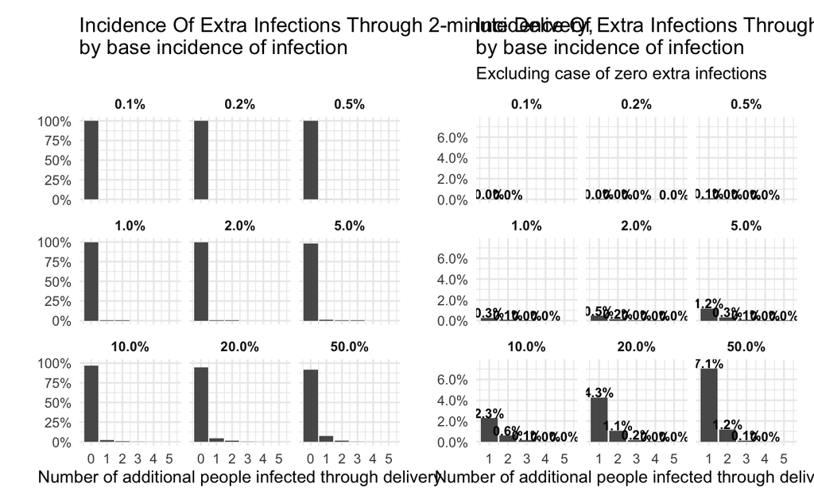

```r
(
deliveries %>%
  ggplot(aes(x=ExtraInfections, y=Proportion)) + geom_col() + facet_wrap(~reorder(scales::percent(Prior, 0.1), Prior)) + scale_x_continuous("Number of additional people infected through delivery", breaks=0:(max(deliveries$ExtraInfections))) + theme_minimal() + scale_y_continuous('', labels=scales::percent) + theme(strip.text = element_text(face='bold')) + ggtitle("Incidence Of Extra Infections Through 2-minute Delivery, \nby base incidence of infection")
) +
  (
    deliveries %>%
  filter(ExtraInfections > 0) %>%
  ggplot(aes(x=ExtraInfections, y=Proportion)) + geom_col() + facet_wrap(~reorder(scales::percent(Prior, 0.1), Prior)) + scale_x_continuous("Number of additional people infected through delivery", breaks=1:(max(deliveries$ExtraInfections))) + theme_minimal() + scale_y_continuous('', labels=scales::percent) + geom_text(aes( label=scales::percent(Proportion, 0.1)), nudge_y=0.005, fontface='bold', size=3) + theme(strip.text = element_text(face='bold')) + ggtitle("Incidence Of Extra Infections Through 2-minute Delivery, \nby base incidence of infection", subtitle="Excluding case of zero extra infections")

  )
```

```r
scales::percent(transmissionProb(20/60, lambda1))
```

```
[1] "1%"
```

Next, let’s just assume that people arrive and leave by a Poisson process. Anyone inside the store at any given point in time can infect anyone else

```r
gc()
```

code for testing

```r
N <- 1000
arrivalInterval <- 10
serviceTime <- 5
initialIncidence <- 0.1
numShopkeepers <- 10
```

OK now let’s admit up to N people into the shop.